← Back to ML Fundamentals • Week 11 of 0–15

# Week 11 — ML Fundamentals

[Open in Colab](https://colab.research.google.com/github/sanketn26/learn-ml/blob/main/notebooks/week-11-saas.ipynb) [Open in VS Code](https://vscode.dev/github/sanketn26/learn-ml/blob/main/notebooks/week-11-saas.ipynb) Open in Jupyter [Download .ipynb](https://raw.githubusercontent.com/sanketn26/learn-ml/main/notebooks/week-11-saas.ipynb)

### 📝 How to Run This Notebook Locally

**1. Clone the repository:**  
`git clone https://github.com/sanketn26/learn-ml.git && cd learn-ml`

**2. Set up environment:**  
`python3 -m venv venv && source venv/bin/activate`  
`pip install jupyter notebook`

**3. Install course dependencies:**  
`pip install numpy pandas scikit-learn matplotlib scipy seaborn`  
`pip install torch`

**4. Open the notebook:**  
`jupyter notebook notebooks/week-11-saas.ipynb`

# Week 11 — Neural Nets, Without the Mystique

**Course:** Applied ML Foundations for SaaS Analytics  
**Who this is for:** Engineers who keep hearing “just use a network.” This week is permission to **not**, plus a picture of what a net actually is.

We will **not** pretend we taught calculus-level backpropagation.

## 🎯 What you will be able to do

- Draw a net as an assembly line of mixers + on/off switches
- See why stacked *linear* layers collapse to one linear layer (so we need activations)
- Regularize with dropout + early stopping, and read a train/val loss curve
- Write the four-line **PyTorch training step**: forward → loss → backward → step
- Decide **GBDT vs net** on a tabular SaaS problem honestly

**Think of it like… an assembly line of mixers.**

Each hidden layer takes the previous numbers, mixes them (weighted sum), then puts each mix through a cheap non-linear switch (ReLU: “if negative, make it 0”). The last mixer outputs a churn score. Training is *credit assignment*: nudge every weight a tiny bit so tomorrow’s score is less wrong. The library does the calculus (backprop). You do the architecture and the data.

**Laptop budget**

No GPU. Aimed at ~8 GB RAM. Training uses a few thousand sampled customers (or short sequences) so this notebook should finish in a **few minutes on CPU**. The ideas are the same if you later set `n=None` and train on all 50k rows.

```python
%matplotlib inline
from pathlib import Path
import sys

import numpy as np
import pandas as pd
import matplotlib.pyplot as plt

# Make the shared style kit importable whether you launch from notebooks/ or repo root
for _p in [Path.cwd(), Path.cwd() / "notebooks", Path.cwd().parent]:
    if (_p / "course_style.py").exists():
        sys.path.insert(0, str(_p))
        break

from course_style import apply_style, setup_plots, find_data_dir

apply_style()
setup_plots()
DATA = find_data_dir()
print(f"Data folder: {DATA}")
print("Laptop mode: no GPU required. Models use a sample so each week finishes in a few minutes on CPU.")

from sklearn.model_selection import train_test_split
from sklearn.preprocessing import StandardScaler, OneHotEncoder
from sklearn.compose import ColumnTransformer
from sklearn.pipeline import Pipeline
from sklearn.linear_model import LogisticRegression
from sklearn.ensemble import GradientBoostingClassifier
from sklearn.neural_network import MLPClassifier
from sklearn.metrics import roc_auc_score
```

```
Data folder: /Users/sanketnaik/workspace/learn-ml/data
Laptop mode: no GPU required. Models use a sample so each week finishes in a few minutes on CPU.
```

## Why activations exist — a 30-second proof

If every layer is just `x → Wx + b`, then two layers are `W2(W1x + b1) + b2`, which is some other `W'x + b'`. You built a logistic regression with extra typing.

ReLU (and friends) break that collapse. That is the whole reason they exist.

```
features ─► mix ─► ReLU ─► mix ─► ReLU ─► mix ─► sigmoid ─► score
              ▲                  ▲
              └── without these switches, the whole tower is one line
```

**Math, translated — backprop in one sentence**

After a batch of examples, we know how wrong the score was. Backprop walks backward through the assembly line and estimates “if I wiggle this weight, does the error go up or down?” Then we wiggle it the helpful way (gradient descent). You will not derive it this week. You will treat it like the compiler: necessary, already written.

```python
# Collapse demo: two linear maps == one linear map
rng = np.random.default_rng(0)
X = rng.normal(size=(5, 3))
W1, b1 = rng.normal(size=(3, 4)), rng.normal(size=4)
W2, b2 = rng.normal(size=(4, 2)), rng.normal(size=2)
two_layers = (X @ W1 + b1) @ W2 + b2
W_eq, b_eq = W1 @ W2, b1 @ W2 + b2
one_layer = X @ W_eq + b_eq
print("Max difference between 2 linear layers and 1 equivalent layer:",
      np.max(np.abs(two_layers - one_layer)))
print("That number should be ~0. Activations are what make depth real.")
```

```
Max difference between 2 linear layers and 1 equivalent layer: 4.440892098500626e-16
That number should be ~0. Activations are what make depth real.
```

## CloudWave bake-off — sklearn MLP vs logistic vs GBT

We use `MLPClassifier` so this week runs **without TensorFlow**. Same idea as Keras `Dense` layers.

```python
from course_style import load_customer_360

df = load_customer_360(DATA)
numeric = ["mrr", "tenure_days", "log_usage", "features_adopted", "total_events", "n_support"]
X = df[numeric + ["plan_type"]]
y = df["is_churned"].astype(int)
X_train, X_test, y_train, y_test = train_test_split(
    X, y, test_size=0.2, random_state=42, stratify=y
)
# A further val split so we can draw a learning curve
X_tr, X_val, y_tr, y_val = train_test_split(
    X_train, y_train, test_size=0.2, random_state=0, stratify=y_train
)
prep = ColumnTransformer([
    ("num", StandardScaler(), numeric),
    ("cat", OneHotEncoder(handle_unknown="ignore"), ["plan_type"]),
])
X_tr_t, X_val_t, X_test_t = prep.fit_transform(X_tr), prep.transform(X_val), prep.transform(X_test)

def report(name, model, Xt=X_tr_t, Xv=X_test_t):
    model.fit(Xt, y_tr if Xt is X_tr_t else y_train)
    # fitted on the matching labels — keep it simple below
    return name, model

results = []
for name, model, xfit, yfit, xeval in [
    ("logreg", LogisticRegression(max_iter=1000), X_tr_t, y_tr, X_test_t),
    ("gbt", GradientBoostingClassifier(n_estimators=40, max_depth=2, random_state=42), X_tr_t, y_tr, X_test_t),
    ("mlp", MLPClassifier(hidden_layer_sizes=(16, 8), activation="relu",
                          max_iter=20, random_state=42), X_tr_t, y_tr, X_test_t),
    ("mlp+dropout-ish", MLPClassifier(hidden_layer_sizes=(16, 8), activation="relu",
                          alpha=0.01, max_iter=20, random_state=42), X_tr_t, y_tr, X_test_t),
]:
    model.fit(xfit, yfit)
    auc = roc_auc_score(y_test, model.predict_proba(xeval)[:, 1])
    results.append((name, auc))
    print(f"{name:<18} AUC={auc:.3f}")
```

```
logreg             AUC=0.591
gbt                AUC=0.588
mlp                AUC=0.571
```

```
mlp+dropout-ish    AUC=0.570
```

## The one plot a net owes you: train vs validation loss

If train loss keeps falling and val loss turns up, you are memorizing. **Early stopping** = take the checkpoint when val was best. **Dropout** (in Keras; here we use `alpha` L2 as the cousin) = randomly break mixers so no single path can memorize.

[output not shown]

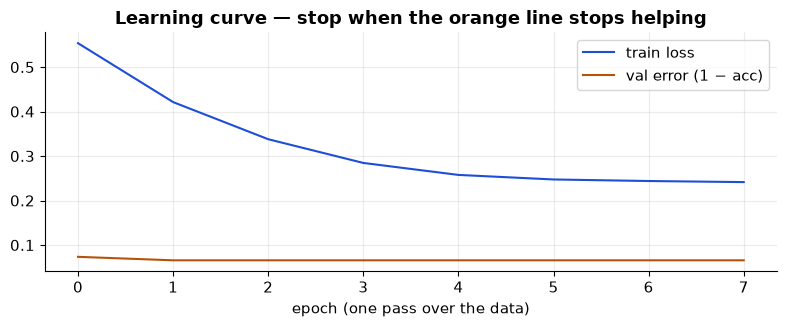

```
Test AUC (early-stopped MLP): 0.473
On this table, GBT is usually equal or better. That is the lesson.
```

```python
mlp = MLPClassifier(hidden_layer_sizes=(24, 12), activation="relu",
                    max_iter=25, random_state=42, early_stopping=True,
                    validation_fraction=0.2, n_iter_no_change=5)
mlp.fit(prep.fit_transform(X_train), y_train)

fig, ax = plt.subplots(figsize=(8, 3.4))
ax.plot(mlp.loss_curve_, label="train loss", color="#1d4ed8")
if hasattr(mlp, "validation_scores_"):
    ax.plot(1 - np.array(mlp.validation_scores_), label="val error (1 − acc)", color="#b45309")
ax.set_xlabel("epoch (one pass over the data)")
ax.set_title("Learning curve — stop when the orange line stops helping")
ax.legend()
plt.tight_layout()
plt.show()

print("Test AUC (early-stopped MLP):",
      f"{roc_auc_score(y_test, mlp.predict_proba(prep.transform(X_test))[:,1]):.3f}")
print("On this table, GBT is usually equal or better. That is the lesson.")
```

## PyTorch — NumPy with a tape recorder

Week 0 promised this. A `torch.tensor` is a NumPy array that **remembers the recipe**. `loss.backward()` walks the recipe and fills `.grad` on every weight. `optimizer.step()` nudges the weights the helpful way.

```
batch of rows
    │  forward
    ▼
  logits → loss
    │  backward  (the library’s calculus)
    ▼
  .grad on every weight
    │  step
    ▼
  slightly less-wrong weights
```

Install once: `pip install torch` (CPU is enough for this course).

```
x       [2.0, 3.0]
y       13.0
x.grad  [4.0, 6.0]   ← d(x1²+x2²)/dx = 2x
```

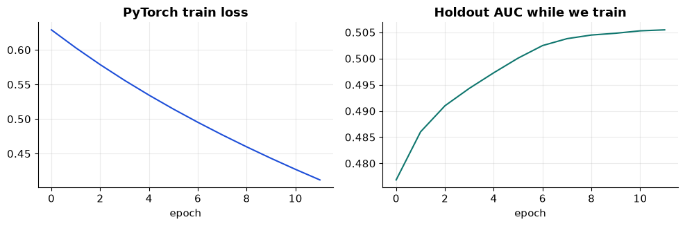

```
Final holdout AUC: 0.505
Remember the four calls: zero_grad → forward → backward → step.
```

```python
try:
    import torch
    import torch.nn as nn
except ImportError:
    raise SystemExit("PyTorch is missing. Install with:  pip install torch") from None

torch.manual_seed(0)
x = torch.tensor([2.0, 3.0], requires_grad=True)
y = (x ** 2).sum()          # 4 + 9 = 13
y.backward()
print("x      ", x.tolist())
print("y      ", float(y))
print("x.grad ", x.grad.tolist(), "  ← d(x1²+x2²)/dx = 2x")

# Same CloudWave table, now as tensors
Xt = torch.tensor(np.asarray(X_tr_t, dtype=np.float32))
yt = torch.tensor(y_tr.to_numpy(), dtype=torch.float32).unsqueeze(1)
Xv = torch.tensor(np.asarray(X_test_t, dtype=np.float32))
yv = torch.tensor(y_test.to_numpy(), dtype=torch.float32).unsqueeze(1)

net = nn.Sequential(
    nn.Linear(Xt.shape[1], 16),
    nn.ReLU(),
    nn.Linear(16, 1),          # one logit; sigmoid lives in the loss
)
opt = torch.optim.Adam(net.parameters(), lr=1e-2)
loss_fn = nn.BCEWithLogitsLoss()

train_losses, val_aucs = [], []
net.train()
for epoch in range(12):
    opt.zero_grad()
    logits = net(Xt)
    loss = loss_fn(logits, yt)
    loss.backward()
    opt.step()
    train_losses.append(float(loss))
    with torch.no_grad():
        scores = torch.sigmoid(net(Xv)).numpy().ravel()
        val_aucs.append(roc_auc_score(y_test, scores))

fig, axes = plt.subplots(1, 2, figsize=(10, 3.4))
axes[0].plot(train_losses, color="#1d4ed8")
axes[0].set_title("PyTorch train loss")
axes[0].set_xlabel("epoch")
axes[1].plot(val_aucs, color="#0f766e")
axes[1].set_title("Holdout AUC while we train")
axes[1].set_xlabel("epoch")
plt.tight_layout()
plt.show()
print(f"Final holdout AUC: {val_aucs[-1]:.3f}")
print("Remember the four calls: zero_grad → forward → backward → step.")
```

**Watch out**

**Ship / don’t ship**

**Tabular SaaS, < ~100k rows, mixed columns → gradient-boosted trees.**  
**Images, text, audio, long sequences → deep learning.**  
A net is not “more serious.” It is a different tool. Pick the one you can monitor at 3 a.m.

## ✍️ Exercises

**1. Linear MLP.** Set `activation="identity"` (no ReLU). Compare AUC to logistic regression. They should rhyme.

**2. Too much net.** `hidden_layer_sizes=(128, 128, 128)` on this data. What happens to train vs test?

**3. Decision memo.** Write five lines to your VP: why CloudWave’s churn model will stay a GBT this quarter.

**4. Break the loop.** Comment out `opt.zero_grad()` and rerun 5 epochs. What happens to the loss? (It should explode or thrash.)

## 🤔 Reflection

1. What problem is the activation function solving, in your own words?
2. Who owns backprop on your team — you, or the library? What do you still own?
3. Name one product surface at CloudWave where a net *would* be the right call (e.g. search ranking on ticket text).
4. In one sentence: what does `loss.backward()` put on each weight?

## 🔗 Next week

Capstone for the *tabular* path. After that: CNNs, RNNs, and Transformers — the architectures you actually mean when you say “deep learning.”

← Previous Week Back to ML Fundamentals Next Week →